# act_report

## Analysis report for WeRateDogs project

- After gathering, assessing and cleaning the Twitter dataset, I had to analyze it and look for insights. Some of the columns that I used in my analysis are Combined_names, name, rating_numerator, retweet_count and favorite_count.

```python
import matplotlib.pyplot as plt
import matplotlib.image as mpimg
bar=mpimg.imread('dog_breed.png')
names=mpimg.imread('names.png')
ratings=mpimg.imread('ratings.png')
tweet_count=mpimg.imread('Tweet_count.png')
```

- To begin with, the first question that I posed was, what is the most popular dog breed, after doing the analysis I found out that the most popular dog breed is pupper and the least is floofer as shown in the bar graph below.

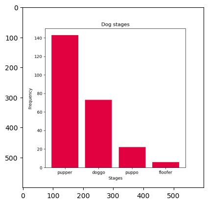

```python
plt.imshow(bar);
```

- Moving on to the second analysis I conducted, I wanted to find out the most popular dog name, from the bar graph I noted that the most popular dog names Oliver, Penny, Tucker and Cooper are equally popular compared to other dog names. Although some of the tweets didn’t have the dog names as depicted below.

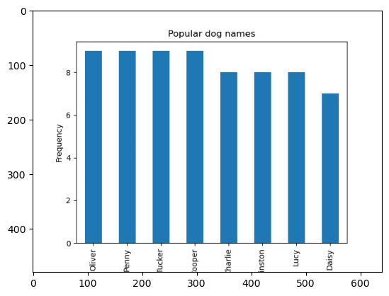

```python
plt.imshow(names);
```

- The third thing that I wanted to know was the highest dog rating. I found out that the highest dog rating was 12 compared to the rest from the pie chart.

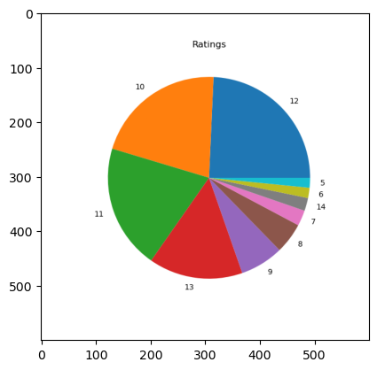

```python
plt.imshow(ratings);
```

- Another interesting insight that I found is the highest retweet and favorite counts which are 69217 and 141431. After taking a good look at the histogram most of the retweet and favorite counts are concentrated on the left.

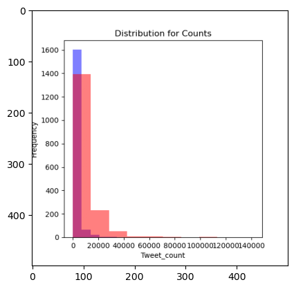

```python
plt.imshow(tweet_count);
```

- From the information, I obtained from the previous analysis, I got intrigued and used the highest retweet count to find out the dog’s breed and rating. I found out that the dog had a rating of 13 which is a bit higher than the most popular rating and the breed was doggo which is less popular than pupper.